# Tutorial 3

2023-07-11

> [*Back to content page*](https://flatter11.github.io/6040/)

A longitudinal study recruited 200 adults aged 60 to 69y to investigate the relation between indoor PM2.5 exposure and black carbon content in airway macrophages (AMBC). Subjects were visited for 5 times in the study. The dataset was saved in ‘ambc.csv’ with the following variables:

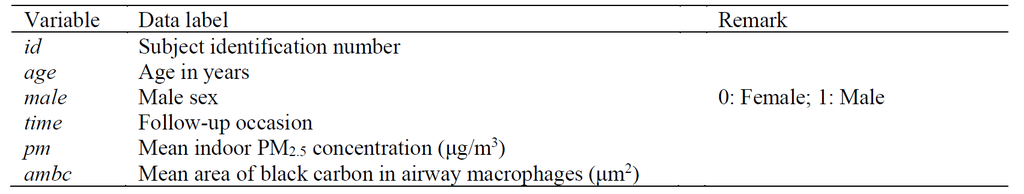

```r
dat <- read.csv('Data/ambc.csv')
head(dat)
```

```
##   id male age time   pm ambc
## 1  1    1  67    1 14.4 0.91
## 2  1    1  67    2 13.1 1.10
## 3  1    1  67    3 14.7 0.94
## 4  1    1  67    4 17.9 1.22
## 5  1    1  67    5 17.3 1.52
## 6  2    1  65    1 18.7 0.95
```

# Basic check of longitudinal data (lecture 5.2 Basic check of data)

## Interaction plot and ICC

1. Read the dataset into R. Plot the pattern of pattern of indoor PM2.5 and AMBC over time. Do you think AMBC are correlated within subjects?

```r
## Correlation by visualization
require(lattice)
```

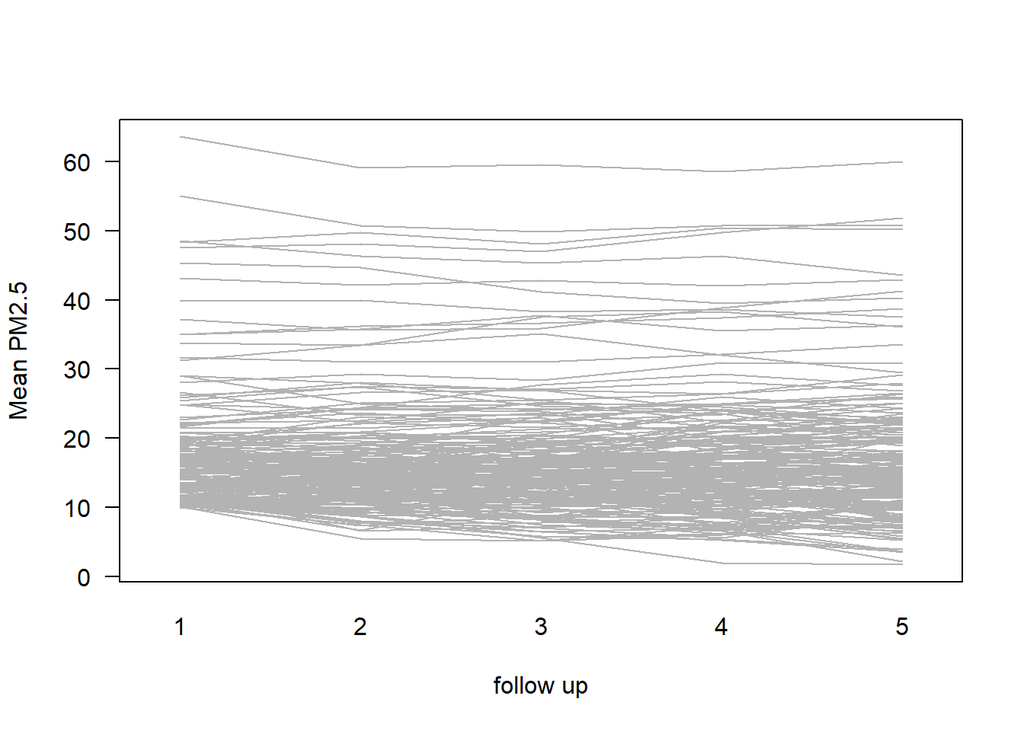

```r
with(dat,interaction.plot(time,id,pm, legend=F, lty=1, col=gray(0.7),
                          xlab='follow up', ylab='Mean PM2.5', las=1))
```

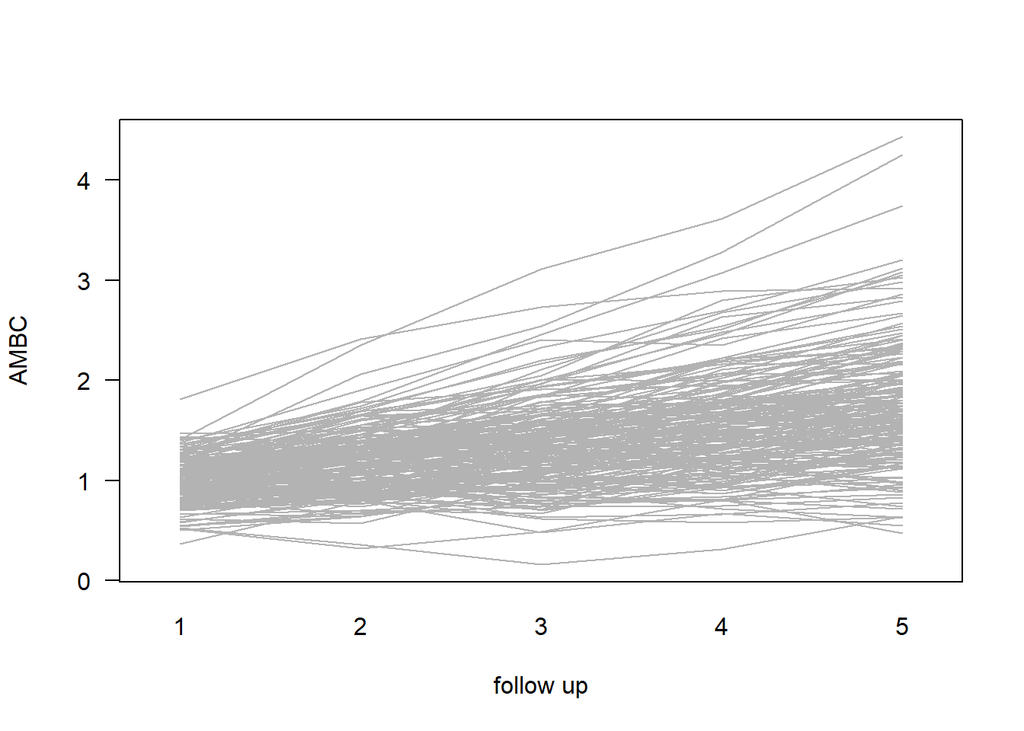

```r
with(dat,interaction.plot(time,id,ambc, legend=F, lty=1, col=gray(0.7),
                          xlab='follow up', ylab='AMBC', las=1))
```

```r
#Can see patern in ambc not pm2.5

## Correlation by ICC
require(ICC)
with(dat, ICCest(as.factor(id), ambc))
```

```
## $ICC
## [1] 0.4494082
##
## $LowerCI
## [1] 0.3832954
##
## $UpperCI
## [1] 0.5182474
##
## $N
## [1] 200
##
## $k
## [1] 5
##
## $varw
## [1] 0.1441268
##
## $vara
## [1] 0.1176403
```

```r
#ICC = 0.45, which suggests moderate correlation between AMBC measurements within subjects
```

## Relationship under grouping (each subject)

2. Explore the relationship between indoor PM2.5 and AMBC content for some subjects

[figure not shown]

```r
## Relation within each subject
xyplot(ambc~pm|id, data=dat, type=c('p','r'))
```

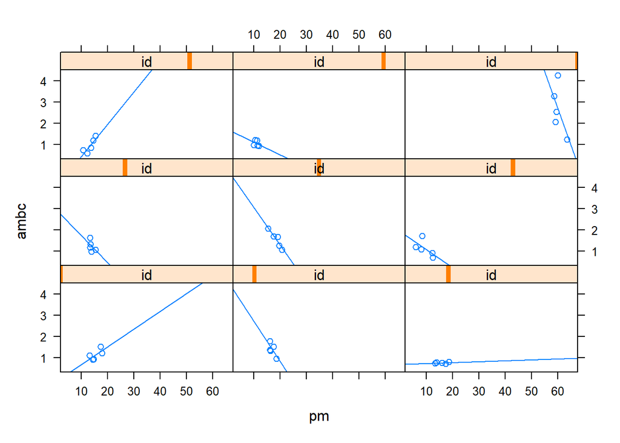

```r
xyplot(ambc~pm|id, data=dat[dat$id < 10,], type=c('p','r'))#Plot out fewer individuals
```

```r
#Can see different patterns
```

## Crude linear regression analysis

3. Fit an ordinary regression model to predict AMBC by age, male, and PM2.5. Summarize your results in the following table:

```r
l0 <- lm(ambc~male+age+pm, data=dat)
summary(l0)
```

```
##
## Call:
## lm(formula = ambc ~ male + age + pm, data = dat)
##
## Residuals:
##      Min       1Q   Median       3Q      Max
## -1.52980 -0.29537 -0.03047  0.24720  2.12138
##
## Coefficients:
##              Estimate Std. Error t value Pr(>|t|)
## (Intercept) -0.485725   0.299536  -1.622   0.1052
## male         0.091067   0.030041   3.031   0.0025 **
## age          0.019957   0.004610   4.330 1.65e-05 ***
## pm           0.029202   0.001592  18.339  < 2e-16 ***
## ---
## Signif. codes:  0 '***' 0.001 '**' 0.01 '*' 0.05 '.' 0.1 ' ' 1
##
## Residual standard error: 0.4357 on 996 degrees of freedom
## Multiple R-squared:  0.2757, Adjusted R-squared:  0.2735
## F-statistic: 126.4 on 3 and 996 DF,  p-value: < 2.2e-16
```

```r
cbind(coef(l0),confint(l0))
```

```
##                               2.5 %     97.5 %
## (Intercept) -0.48572531 -1.07351998 0.10206937
## male         0.09106654  0.03211479 0.15001829
## age          0.01995708  0.01091158 0.02900257
## pm           0.02920197  0.02607719 0.03232676
```

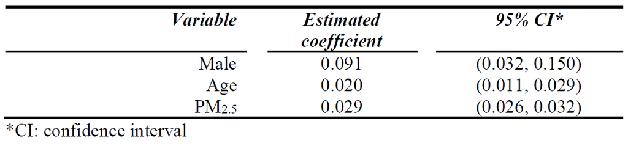

# GEE (lecture 6)

## Fitting GEE

4. Fit a generalized estimating equation (GEE) model to predict AMBC by age, male, and PM2.5, by assuming independence, exchangeable, AR(1) and unstructured correlation structure.

```r
## Fit GEE with different correlation structure; gaussian distribution coz continuous variables
library(geepack)
g.indp <- geeglm(ambc~male+age+pm, family=gaussian, id=id, corstr="independence", data=dat)
g.exch <- geeglm(ambc~male+age+pm, family=gaussian, id=id, corstr="exchangeable", data=dat)
g.ar1 <- geeglm(ambc~male+age+pm, family=gaussian, id=id, corstr="ar1", data=dat)
g.unstr <- geeglm(ambc~male+age+pm, family=gaussian, id=id, corstr="unstructured", data=dat)
```

## Compare GEE models

5. Select the best model from (d).

```r
library(MESS)
QIC(g.indp); QIC(g.exch); QIC(g.ar1); QIC(g.unstr)
```

```
##        QIC       QICu  Quasi Lik        CIC     params       QICC
## 204.984553 197.072951 -94.536475   7.955801   4.000000 205.024754
```

```
##        QIC       QICu  Quasi Lik        CIC     params       QICC
## 205.399499 197.194867 -94.597434   8.102316   4.000000 205.459861
```

```
##        QIC       QICu  Quasi Lik        CIC     params       QICC
## 204.579477 197.176673 -94.588337   7.701402   4.000000 204.639839
```

```
##         QIC        QICu   Quasi Lik         CIC      params        QICC
##  214.301750  210.025196 -101.012598    6.138277    4.000000  214.728146
```

```r
#QIC difference of 5 is significant. Therefore, exchangeable or ar1 fitted better
#OR GEE with AR(1) structure was selected.
```

## Summarize GEE findings

6. Summarize your results from the selected model in (e) in the following table:

```r
## Obtain estimate
summary(g.ar1)
```

```
##
## Call:
## geeglm(formula = ambc ~ male + age + pm, family = gaussian, data = dat,
##     id = id, corstr = "ar1")
##
##  Coefficients:
##              Estimate   Std.err    Wald Pr(>|W|)
## (Intercept) -0.485311  0.409670   1.403  0.23616
## male         0.095505  0.039130   5.957  0.01466 *
## age          0.020212  0.006465   9.774  0.00177 **
## pm           0.028042  0.002252 155.108  < 2e-16 ***
## ---
## Signif. codes:  0 '***' 0.001 '**' 0.01 '*' 0.05 '.' 0.1 ' ' 1
##
## Correlation structure = ar1
## Estimated Scale Parameters:
##
##             Estimate Std.err
## (Intercept)   0.1892 0.01436
##   Link = identity
##
## Estimated Correlation Parameters:
##       Estimate Std.err
## alpha   0.4841 0.03549
## Number of clusters:   200  Maximum cluster size: 5
```

```r
## Obtain 95%CI
library(doBy)
# beta2: male
c(esticon(g.ar1,  c(0,1,0,0))$lwr,esticon(g.ar1,  c(0,1,0,0))$upr)
```

```
## [1] 0.01881 0.17220
```

```r
# beta3: age
c(esticon(g.ar1, c(0,0,1,0))$lwr,esticon(g.ar1, c(0,0,1,0))$upr)
```

```
## [1] 0.007541 0.032883
```

```r
# beta4: pm
c(esticon(g.ar1, c(0,0,0,1))$lwr,esticon(g.ar1, c(0,0,0,1))$upr)
```

```
## [1] 0.02363 0.03246
```

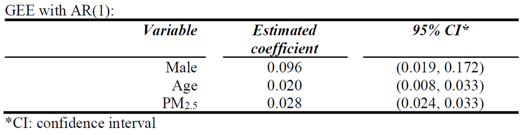

# LMM (lecture 5)

## Fitting LMM (random intercept)

7. Fit a linear mixed model with random intercept to predict AMBC by age, male, and PM2.5. Summarize your results in the following table:

```r
require(lme4)
lme1 <- lmer(ambc~male+age+pm+(1|id), data=dat)
summary(lme1) #Estimate
```

```
## Linear mixed model fit by REML ['lmerMod']
## Formula: ambc ~ male + age + pm + (1 | id)
##    Data: dat
##
## REML criterion at convergence: 1123
##
## Scaled residuals:
##    Min     1Q Median     3Q    Max
## -3.961 -0.625 -0.071  0.545  4.494
##
## Random effects:
##  Groups   Name        Variance Std.Dev.
##  id       (Intercept) 0.0452   0.213
##  Residual             0.1454   0.381
## Number of obs: 1000, groups:  id, 200
##
## Fixed effects:
##             Estimate Std. Error t value
## (Intercept) -0.44752    0.41876   -1.07
## male         0.09441    0.04201    2.25
## age          0.01967    0.00645    3.05
## pm           0.02789    0.00216   12.93
##
## Correlation of Fixed Effects:
##      (Intr) male   age
## male  0.035
## age  -0.994 -0.093
## pm   -0.150 -0.130  0.072
```

```r
confint(lme1, method="Wald") #95CI
```

```
##                 2.5 %  97.5 %
## .sig01             NA      NA
## .sigma             NA      NA
## (Intercept) -1.268272 0.37323
## male         0.012076 0.17674
## age          0.007037 0.03231
## pm           0.023658 0.03211
```

```r
cbind(lme1@beta[-1],confint(lme1, method="Wald")[-c(1:3),]) #better presentation of estimate and 95CI
```

```
##                 2.5 %  97.5 %
## male 0.09441 0.012076 0.17674
## age  0.01967 0.007037 0.03231
## pm   0.02789 0.023658 0.03211
```

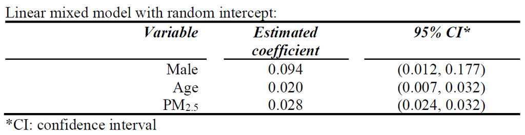

## Check ICC

8. Calculate the intraclass correlation (ICC) for the model in (g).

```r
0.0452/(0.0452+0.1454)
```

```
## [1] 0.2371
```

## Fitting linear mixed model (random intercept and slope)

1. Fit a linear effects model with random intercept and slope to predict AMBC by age, male, and PM2.5. Summarize your results in the table below and compare your results with that in (g).

```r
lme2 <- lmer(ambc~male+age+pm+(1+pm|id), data=dat)
summary(lme2) #Estimate
```

```
## Linear mixed model fit by REML ['lmerMod']
## Formula: ambc ~ male + age + pm + (1 + pm | id)
##    Data: dat
##
## REML criterion at convergence: 1120
##
## Scaled residuals:
##    Min     1Q Median     3Q    Max
## -3.966 -0.624 -0.070  0.552  4.259
##
## Random effects:
##  Groups   Name        Variance Std.Dev. Corr
##  id       (Intercept) 0.081087 0.2848
##           pm          0.000129 0.0113   -0.72
##  Residual             0.143868 0.3793
## Number of obs: 1000, groups:  id, 200
##
## Fixed effects:
##             Estimate Std. Error t value
## (Intercept) -0.51698    0.42196   -1.23
## male         0.09244    0.04210    2.20
## age          0.02098    0.00648    3.23
## pm           0.02689    0.00270    9.95
##
## Correlation of Fixed Effects:
##      (Intr) male   age
## male  0.053
## age  -0.992 -0.108
## pm   -0.171 -0.134  0.077
## optimizer (nloptwrap) convergence code: 0 (OK)
## Model failed to converge with max|grad| = 0.0231805 (tol = 0.002, component 1)
```

```r
confint(lme2, method="Wald") #95CI
```

```
##                 2.5 %  97.5 %
## .sig01             NA      NA
## .sig02             NA      NA
## .sig03             NA      NA
## .sigma             NA      NA
## (Intercept) -1.344006 0.31005
## male         0.009913 0.17496
## age          0.008267 0.03369
## pm           0.021595 0.03219
```

```r
cbind(lme2@beta[-1],confint(lme2, method="Wald")[-c(1:5),])#better presentation of estimate and 95CI
```

```
##                 2.5 %  97.5 %
## male 0.09244 0.009913 0.17496
## age  0.02098 0.008267 0.03369
## pm   0.02689 0.021595 0.03219
```

```r
#Note variance of random effect slope is small (0.000129) so it won't change ans too much
```

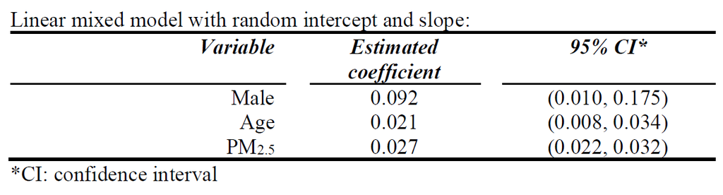

## Summarize above findings

10. Compare the results in (a)-(i) from different methods.

All estimates are similar from different models, but the linear regression model is likely to have underestimated the uncertainty. (95%CI for linear regression is tighter coz it wrongly ignored the uncertainty of grouping)

# Penalty regression (lecture 8)

## Regression with traditional method (problem of multicollinearity)

11. Suppose it is also interesting to investigate how the previous mean indoor PM2.5 concentrations will affect the AMBC at the 5th visit. Fit a linear regression for the purpose and summarize your results in the table below: [hint: convert data to wide format] (lecture 6)

```r
## Convert from long to wide format
data.wide <- reshape(dat, v.names=c("pm","ambc"),
                     idvar="id", timevar="time", direction="wide")
head(data.wide)
```

```
##    id male age pm.1 ambc.1 pm.2 ambc.2 pm.3 ambc.3 pm.4 ambc.4 pm.5 ambc.5
## 1   1    1  67 14.4   0.91 13.1   1.10 14.7   0.94 17.9   1.22 17.3   1.52
## 6   2    1  65 18.7   0.95 16.4   1.33 16.1   1.36 16.1   1.78 17.5   1.53
## 11  3    0  62 13.4   0.73 14.0   0.78 16.1   0.77 18.6   0.80 17.5   0.72
## 16  4    1  63 15.5   1.07 13.3   1.17 13.8   0.98 13.5   1.32 13.4   1.62
## 21  5    0  67 20.8   1.07 19.6   1.26 19.1   1.67 17.6   1.69 15.4   2.06
## 26  6    0  61 12.6   0.70 12.3   0.91  8.1   1.09  6.1   1.20  8.5   1.72
```

```r
## Fit lr to predict measure at 5th visit -- but hv multicollinearity (measure at 1-4th visit are highly correlated)
l.multi <- lm(ambc.5~male+age+pm.1+pm.2+pm.3+pm.4+pm.5, data=data.wide)
summary(l.multi)
```

[output not shown]

```r
confint(l.multi)
```

```
##                 2.5 %   97.5 %
## (Intercept) -2.694745 -0.08329
## male        -0.001469  0.26308
## age          0.013958  0.05415
## pm.1        -0.026474  0.03506
## pm.2        -0.033702  0.05263
## pm.3        -0.017747  0.06863
## pm.4        -0.068535  0.02250
## pm.5         0.003202  0.06398
```

```r
cbind(coef(l.multi),confint(l.multi))
```

```
##                           2.5 %   97.5 %
## (Intercept) -1.389016 -2.694745 -0.08329
## male         0.130805 -0.001469  0.26308
## age          0.034051  0.013958  0.05415
## pm.1         0.004293 -0.026474  0.03506
## pm.2         0.009465 -0.033702  0.05263
## pm.3         0.025443 -0.017747  0.06863
## pm.4        -0.023016 -0.068535  0.02250
## pm.5         0.033592  0.003202  0.06398
```

```r
## Test multicollinearity with vif (Variance Inflation Factor)
require(car)
vif(l.multi)
```

```
##   male    age   pm.1   pm.2   pm.3   pm.4   pm.5
##  1.054  1.020 18.928 37.213 38.694 46.261 21.968
```

```r
#variance of estimate of pm1 in this multiregression compared with variance in regression only adjusted for pm1
#multicollinearity => high variance in multiregression => high vif
```

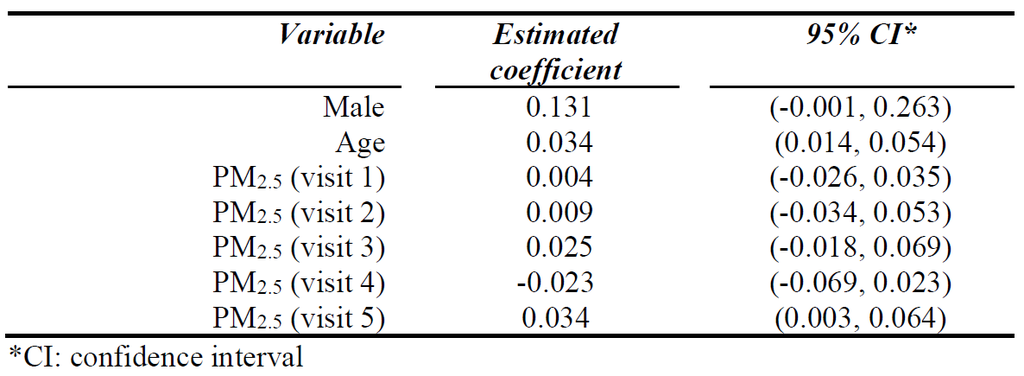

## LASSO regression

12. Perform a LASSO regression and select the optimal λ by cross-validation method.

```r
x <- model.matrix(ambc.5~-1+male+age+pm.1+pm.2+pm.3+pm.4+pm.5, data=data.wide)
y <- data.wide$ambc.5

require(glmnet)
```

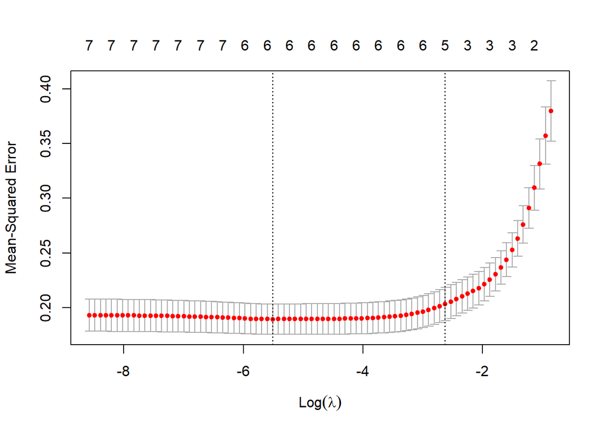

```r
lasso.cv <- cv.glmnet(x,y,alpha=1)
plot(lasso.cv)
```

```r
lambda.cv <- lasso.cv$lambda.min

## lambda if mininum is used
lasso.opt <- glmnet(x, y, alpha=1, lambda=lambda.cv)
coef(lasso.opt)
```

```
## 8 x 1 sparse Matrix of class "dgCMatrix"
##                   s0
## (Intercept) -1.28680
## male         0.11814
## age          0.03272
## pm.1         0.00385
## pm.2         0.00981
## pm.3         0.01369
## pm.4         .
## pm.5         0.02189
```

```r
## lambda if 1-se rule is used
lambda.1se <- lasso.cv$lambda.1se
lasso.1se <- glmnet(x, y, alpha=1, lambda=lambda.1se)
coef(lasso.1se)
```

```
## 8 x 1 sparse Matrix of class "dgCMatrix"
##                  s0
## (Intercept) 0.37964
## male        .
## age         0.01019
## pm.1        .
## pm.2        0.01124
## pm.3        0.01293
## pm.4        .
## pm.5        0.01730
```

[figure not shown]